# Mercator dissolved oxygen and temperature validation

Author

Emily Nazario

Published

May 13, 2024

For the Mercator temperature data, it is important to note that this data was downloaded along the model grid (ORCA grid). When I tried to reset the extent to degrees to be compared to the WOA, OISST, and CalCofi data, the spatial resolution was no longer behaving as expected (the values diverged from the 1/4 degree resolution that is stated in the product’s documentation on the Mercator website). I have email Mercator and Copernicus to see if there is other processing that needs to happen with this dataset to ensure that the spatial extents are correct. In the meantime, to move on with this analysis, I resampled the temperature data as is along the spatial geometries that align with the other data products, though I anticipate that this could result in slight spatial differences in the location of a given temperature value and could cause larger differences in reported temperatures across products.

## DO (mmol/L) at 0m

### Mean across study period (2003-2015)

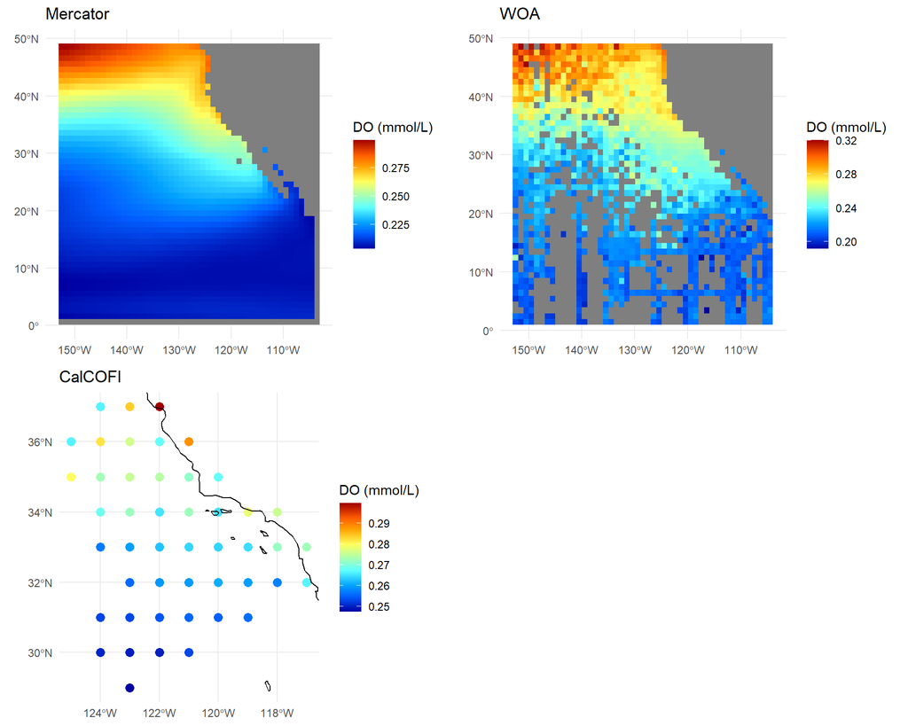

### Mercator difference plots

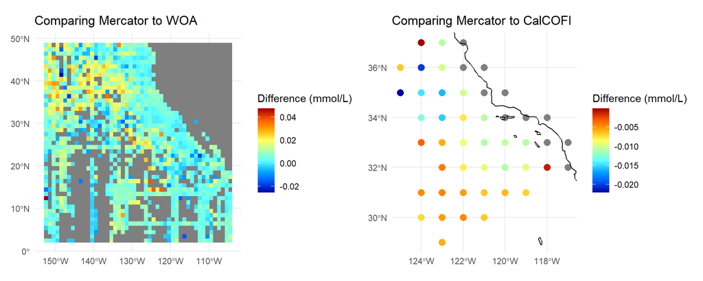

### Mercator temporal variation vs. CalCOFI data 0m

Here, the mercator dissolved oxygen rasters were subset the month-day-year that a CalCOFI bottle sample was collected. The plotted mercator values represent the closest grid cell to that CalCOFI station when a sample was collected. A daily temporal resolution was possible here.

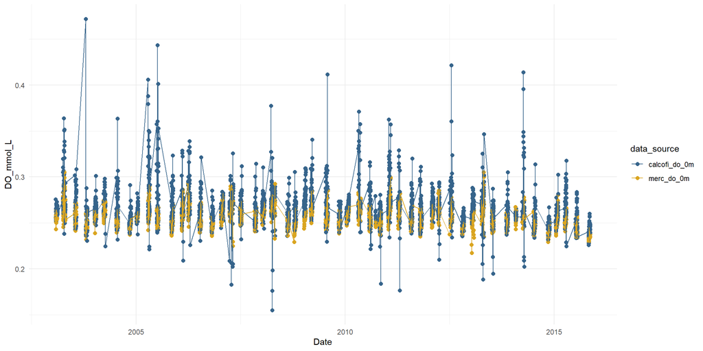

## DO (mmol/L) at 200m

### Mean across study period (2003-2015)

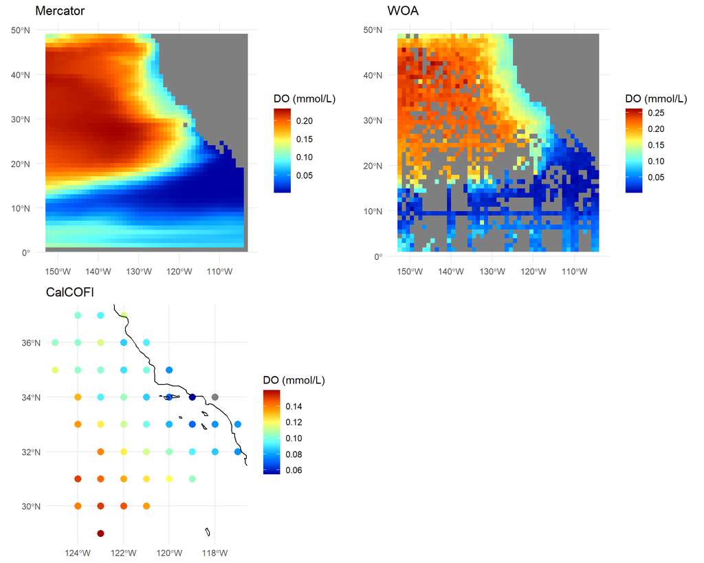

### Mercator difference plots

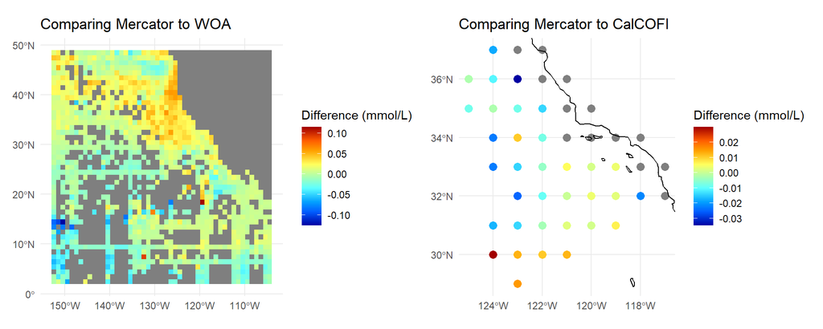

### Mercator temporal variation vs. CalCOFI data 200m

Here, the mercator dissolved oxygen rasters were subset the month-day-year that a CalCOFI bottle sample was collected. The plotted mercator values represent the closest grid cell to that CalCOFI station when a sample was collected. A daily temporal resolution was possible here.

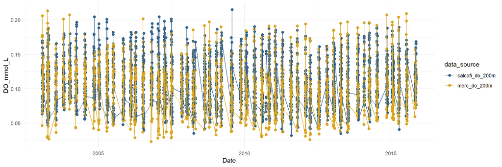

## Temp (C) at 0m

### Mean across study period (2003-2015)

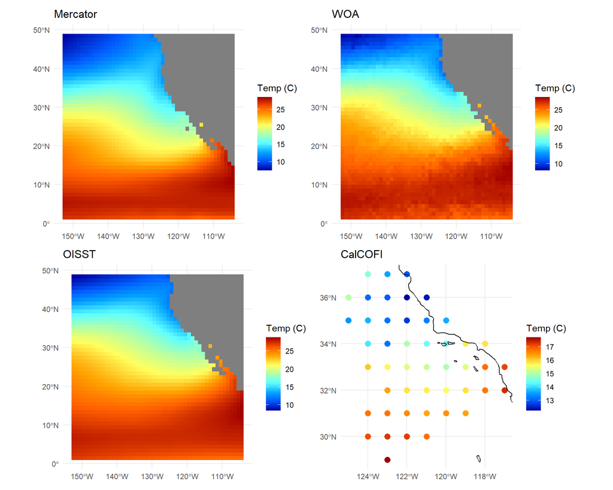

### Mercator difference plots

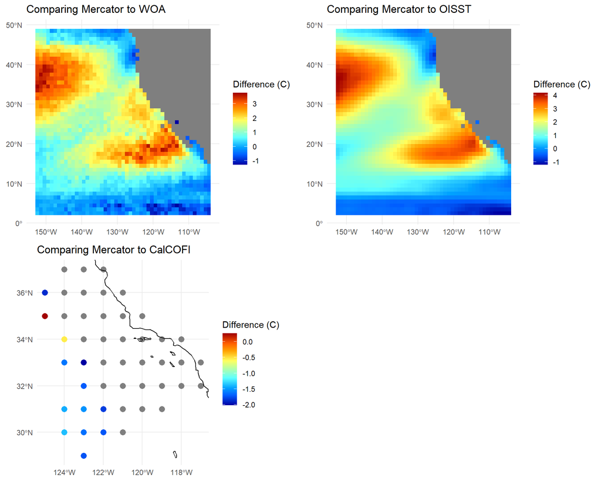

### Mercator temporal variation vs. CalCOFI data 0m

Here, the mercator temperature rasters were subset the month-year that a CalCOFI bottle sample was collected. The plotted mercator values represent the closest grid cell to that CalCOFI station when a sample was collected. A monthly temporal resolution was possible here and not daily due to computational power of extracting the mercator temperature data directly from mercator rather than Copernicus, which is how the dissolved oxygen rasters were obtained.

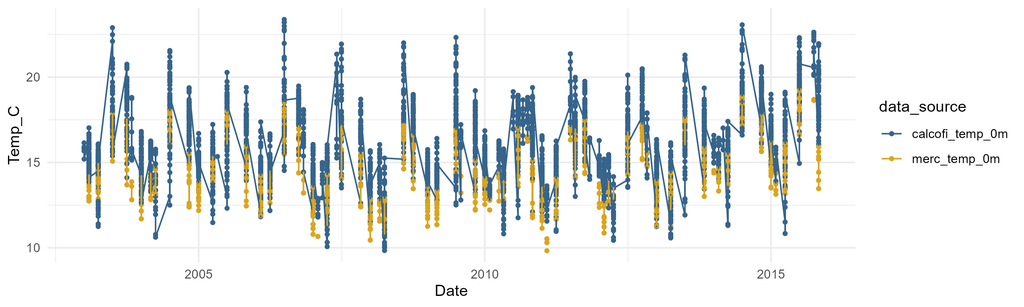

## Temp (C) at 200m

### Mean across study period (2003-2015)

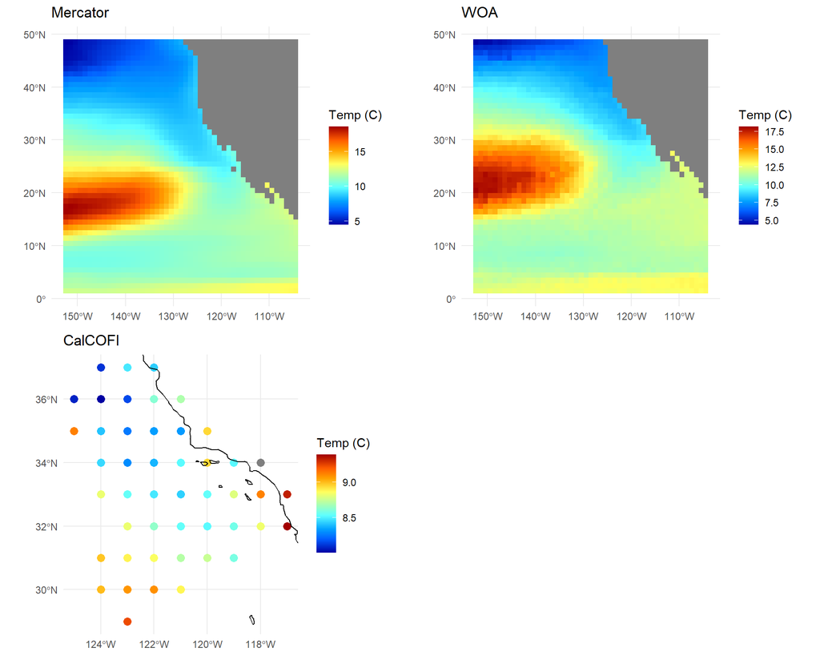

### Mercator difference plots

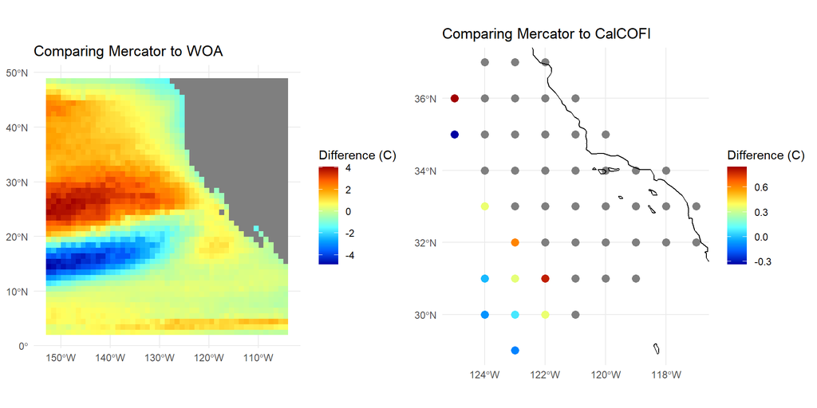

### Mercator temporal variation vs. CalCOFI data 200m

Here, the mercator temperature rasters were subset the month-year that a CalCOFI bottle sample was collected. The plotted mercator values represent the closest grid cell to that CalCOFI station when a sample was collected. A monthly temporal resolution was possible here and not daily due to computational power of extracting the mercator temperature data directly from mercator rather than Copernicus, which is how the dissolved oxygen rasters were obtained.

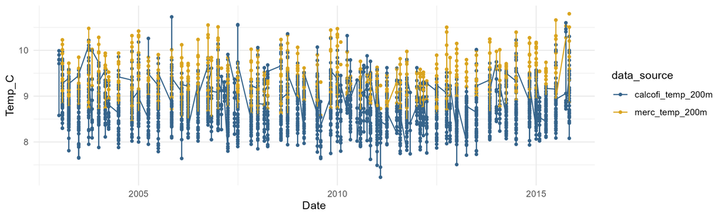